# Pràctica 7 — Problema 6

Anàlisi de Dades 2024-25

Autor/a

Miquel Àngel Aguiló, Joan Camps, Gerard Ribas

Publicat

18 de desembre de 2024

Enllaç [git](https://github.com/JoanCT/Practica7_AD).

## Enunciat

La sèrie temporal [ts_1](https://github.com/igmuib/Practica_AD/blob/main/ts_1.csv) correspon a les vendes (en milers d’unitats) d’un producte en una empresa durant diversos trimestres consecutius. L’empresa cerca desenvolupar un model de pronòstic per predir les vendes futures del producte. Per això, dividiu la sèrie temporal en dos trossos: un 80% de les primeres observacions les utilitzareu per “aprendre” i deixareu el 20% restant per avaluar la capacitat predictiva del model.

**(6.1)** Descriviu la sèrie temporal d’aprenentatge: gràfic de la sèrie original, detecció de la tendència, anàlisi de la variabilitat i estacionalitat (en el cas que apliqui).

**(6.2)** Analitzau els gràfics ACF i PACF. Descomposau la sèrie d’acord amb un model additiu i un de multiplicatiu, seleccioneu el millor. Finalment, feis prediccions amb el model additiu o multiplicatiu que heu seleccionat, dibuixau els vostres pronòstics sobre la sèrie total (aprenentatge + test). Calculau l’error quadràtic mitjà de les prediccions i comentau el resultat en el context del problema.

## Introducció

Les dades s’han descarregat de l’enllaç de l’enunciat al fitxer `ts.csv` i només presenta un llistat numèric del nombre de vendes en milers d’unitats, que conformen la sèrie temporal, dividida en trimestres.

Primerament, farem una anàlisi exploratòria de la sèrie, estudiant la seva tendència, estacionalitat i cercar cicles en aquesta. Per això, representam la sèrie i estudiarem els gràfics ACF i PACF.

Un cop fet això, mirarem d’ajustar la sèrie amb els models multiplicatiu i additiu, els compararem per veure quin dels dos s’ajusta millor a la sèrie, farem unes prediccions dels 12 següents trimestres i els compararem amb els valors reals, calculant el seu error quadràtic mitjà.

## Anàlisi exploratòria

En primer lloc, notem que tenim 48 dades, és a dir, 12 períodes complets de quatre trimestres. Emperò, el 80% de 48 dona aproximadament 38, que no és múltiple del període. Aleshores, per facilitar l’anàlisi agafarem les primeres 36 mostres (el 75%, que correspon a 9 períodes) d’aprenentatge, i deixarem les 12 restants (3 períodes) per les prediccions.

Una vegada agafat el nombre de mostres, dibuixem la sèrie temporal de dades (el primer 75%) per tenir una primera visió de les dades. Com que no tenim cap informació del començament de la sèrie, enumerarem la sèrie començant pel període 1, on cada període té una durada d’un any (quatre trimestres), tot i que no té perquè començar al gener ja que no tenim informació al respecte.

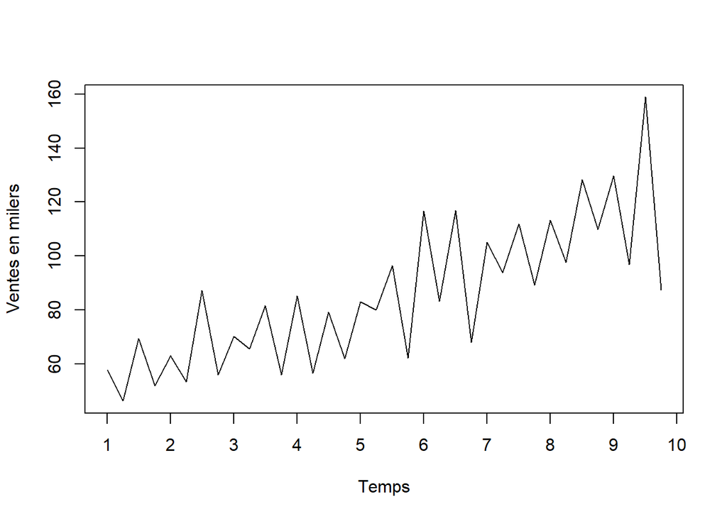

A simple vista es pot apreciar un comportament oscil·lant i amb presència d’estacionalitat, ja que les oscil·lacions presenten un patró determinat corresponent a les estacions. Ara bé, no podem saber si hi ha més vendes a l’hivern i estiu o a la primavera i tardor, idò no tenim informació sobre el començament de la sèrie. En el cas que la sèrie començàs pel primer (o tercer) trimestre de l’any, podria tractar-se d’una tenda de roba genèrica, i les vendes es concentraríen en els trimestres 1 i 3 de l’any, per mor de les rebaixes del gener i del juliol. Altrament, si la sèrie començàs al segon (o quart) semestre de l’any, es podria tractar de venda de roba d’entretemps, ja que es vendria més a la tardor i primavera.

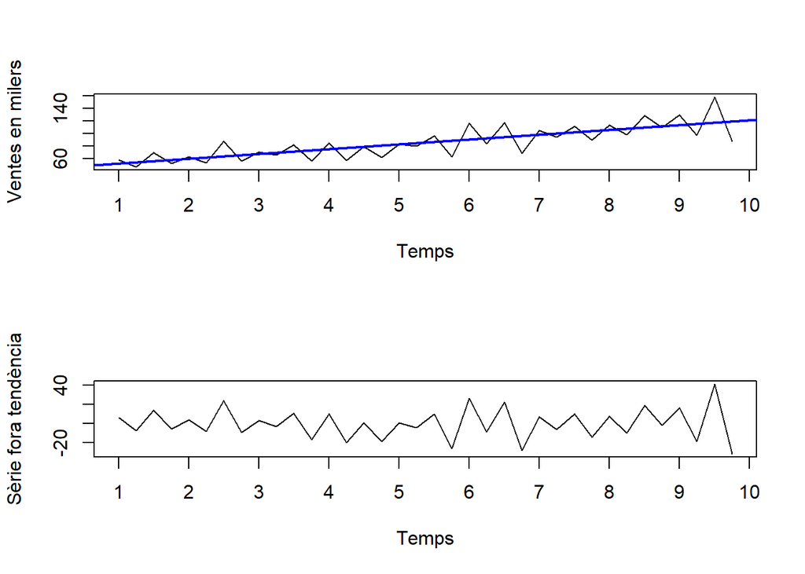

A més, presenta una tendència clarament positiva (començam al voltant dels 60 milers i acabam al voltant del 120 milers). També s’aprecia una variabilitat més o manco constant, tot i que hi ha alguns períodes (6-7 o 9-10) amb pics més grans. Finalment, no s’aprecia cap fluctuació cíclica, la sèrie pareix bastant constant, tenint en compte l’estacionalitat i la tendència.

També podem estudiar l’estacionalitat amb un boxplot per cadascun dels trimestres.

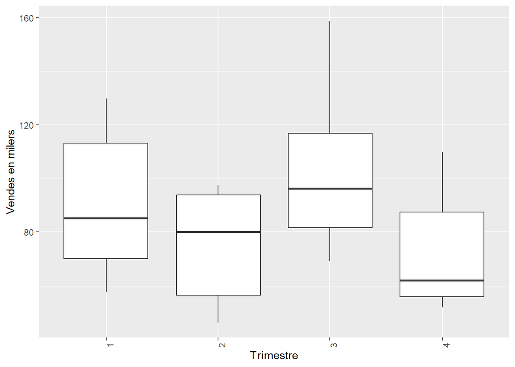

Es pot apreciar que hi ha diferències significatives en les mitjanes del nombre de vendes depenent del trimestre. Per confirmar-ho, durem a terme una ANOVA, comprovant primer la normalitat i homocedasticitat de les dades.

```
    Shapiro-Wilk normality test

data:  df_aux$data
W = 0.95086, p-value = 0.1113
```

```
    Bartlett test of homogeneity of variances

data:  data by mes2
Bartlett's K-squared = 1.5703, df = 3, p-value = 0.6661
```

```
            Df Sum Sq Mean Sq F value Pr(>F)
mes2         3   6007  2002.3   3.552 0.0251 *
Residuals   32  18037   563.7
---
Signif. codes:  0 '***' 0.001 '**' 0.01 '*' 0.05 '.' 0.1 ' ' 1
```

```
    Pairwise comparisons using paired t tests

data:  df_aux$data and df_aux$mes2

  1      2      3
2 0.0115 -      -
3 0.0235 0.0021 -
4 0.0159 0.3520 0.0036

P value adjustment method: holm
```

### ACF i PACF

Vegem els gràfics ACF i PACF.

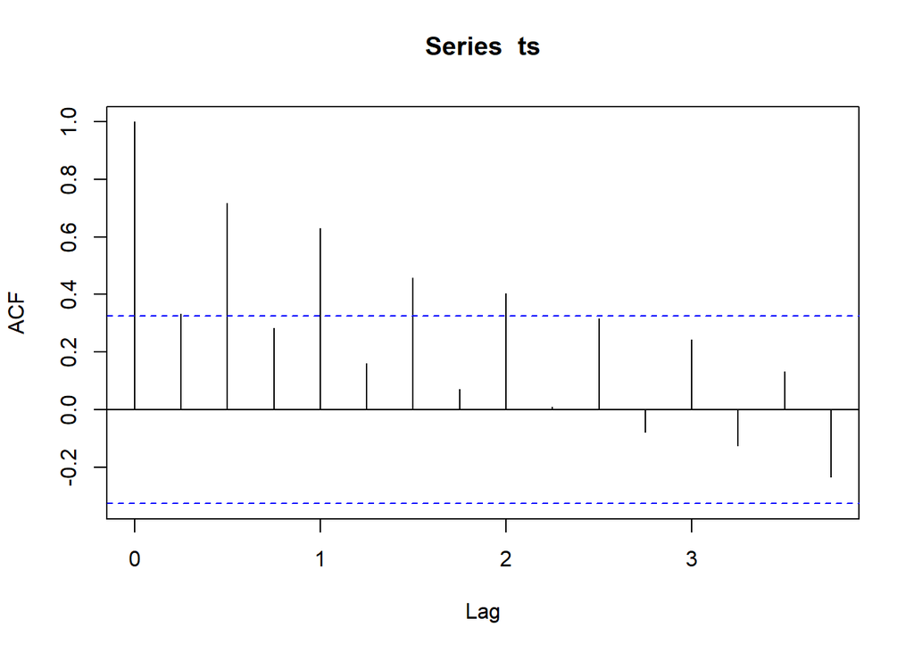

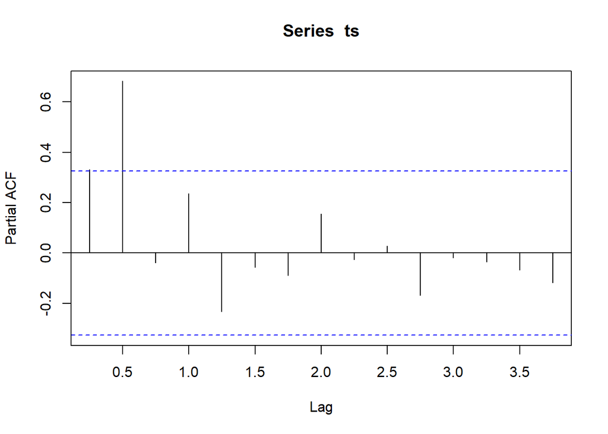

En el primer gràfic (ACF) es pot observar una clara estacionalitat, idò s’aprecia un comportament oscil·lant i repetitiu. A més, les correlacions decreixen a poc a poc degut a la tendència. Pel que fa al PACF, es pot veure que una observació influeix significativament a dos trimestres més endavant (també influeix al següent però de manera no tan significativa).

## Models additiu i multiplicatiu

En aquesta secció aplicarem els models additiu i multiplicatiu a la sèrie temporal i els compararem per determinar el millor per tal de fer els pronòstics.

El model additiu ve donat per $y_t = \mu_t + S_t + a_t$. Empram la funció pròpia de R per veure aquesta descomposició.

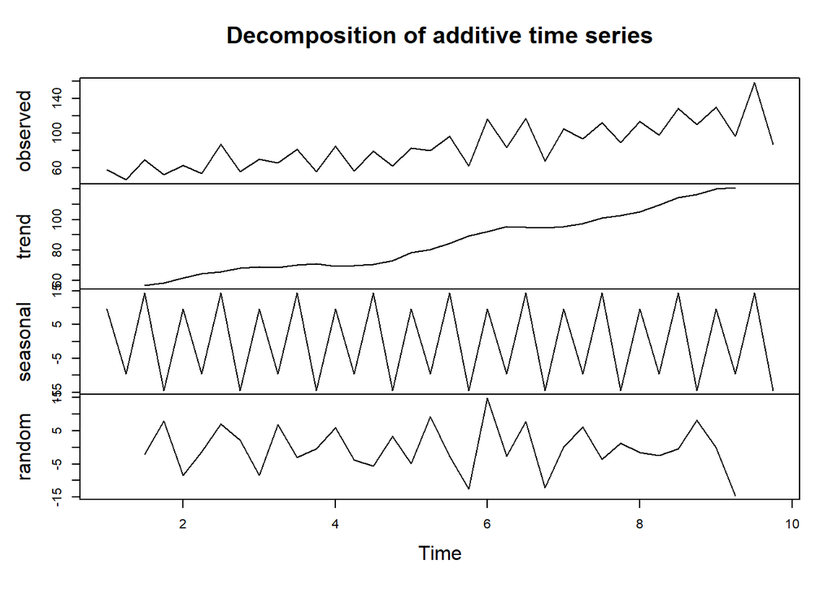

Com es pot apreciar, hi ha una tendència creixent i una forta estacionalitat. Vegem ara el multiplicatiu, que ve donat per $y_t = \mu_t \cdot S_t \cdot a_t$, amb la funció pròpia de R.

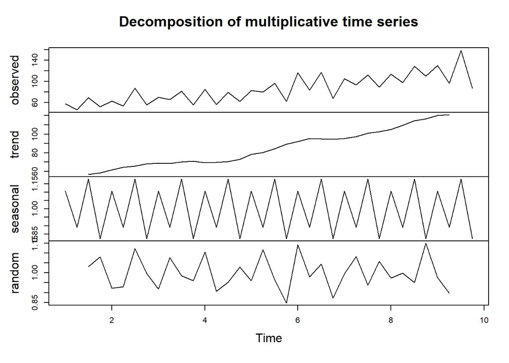

De la mateixa manera es veu una tendència creixent, estacionalitat i, comparant-ho amb l’additiu, no s’aprecien moltes diferències.

Ara bé, aquests models no podrem emprar-los per predir valors futurs, perquè la tendència calculada en ambdós models no la podem estendre en el futur (ja que es calcula fent servir una mitjana mòbil), i per tant no podem fer prediccions a partir de la descomposició així calculada. Per això, simplificarem els models calculant manualment la tendència i l’estacionalitat amb l’objectiu de donar-los una expressió que ens permeti fer els pronòstics.

### Simplificació dels models

Per a poder fer prediccions futures, prendrem com a tendència de la sèrie la recta de regressió. A partir d’aquesta, i restant-la (model additiu) o dividint-la (model multiplicatiu), obtenim una sèrie (diguem-li `ts2`) fora tendència de la qual podem extreure’n els components estacionals.

Comprovem primer que la recta de regressió (com a aproximació de la tendència) és prou bona:

```
Call:
lm(formula = data ~ time(ts))

Residuals:
    Min      1Q  Median      3Q     Max
-31.690  -9.254  -0.346  10.229  41.704

Coefficients:
            Estimate Std. Error t value Pr(>|t|)
(Intercept)   43.656      6.404   6.817 7.64e-08 ***
time(ts)       7.739      1.073   7.214 2.40e-08 ***
---
Signif. codes:  0 '***' 0.001 '**' 0.01 '*' 0.05 '.' 0.1 ' ' 1

Residual standard error: 16.72 on 34 degrees of freedom
Multiple R-squared:  0.6048,    Adjusted R-squared:  0.5932
F-statistic: 52.04 on 1 and 34 DF,  p-value: 2.4e-08
```

Com que els coeficients són significatius i l’R quadrat ajustat és de quasi 0.6, ens donam per satisfets amb l’aproximació. De fet, notem que el pendent és positiu (i és significatiu) i, per tant, la sèrie té tendència creixent, com ja sabíem.

Per extreure els components estacionals, restam (cas additiu) o dividim (cas multiplicatiu) la mitjana de la sèrie `ts2` a la mitjana de cada mateix trimestre de l’any. Finalment, restam (cas additiu) o dividim (cas multiplicatiu) aquests coeficients a `ts2` per obtenir els residus dels models.

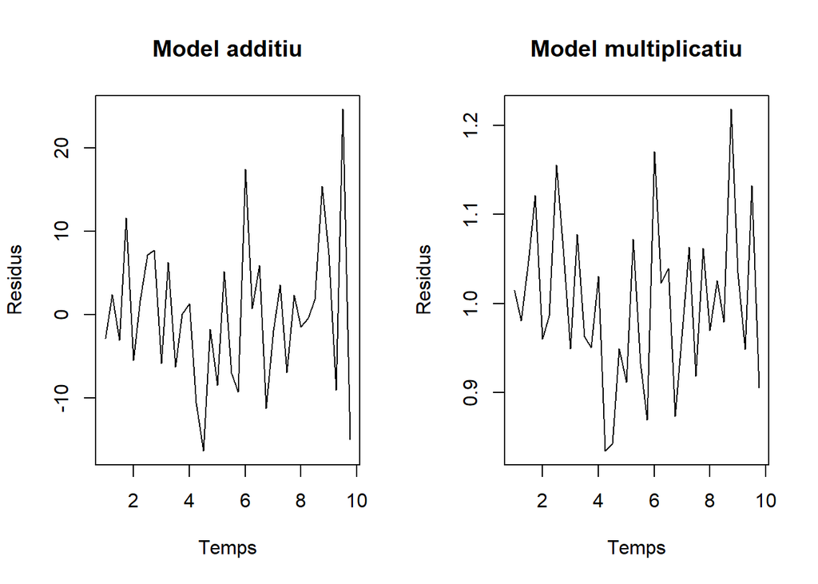

Per veure si són bons models, anem a veure si els errors segueixen una distribució normal amb distribució constant i mitjanes 0 (cas additiu) o 1 (cas multiplicatiu)

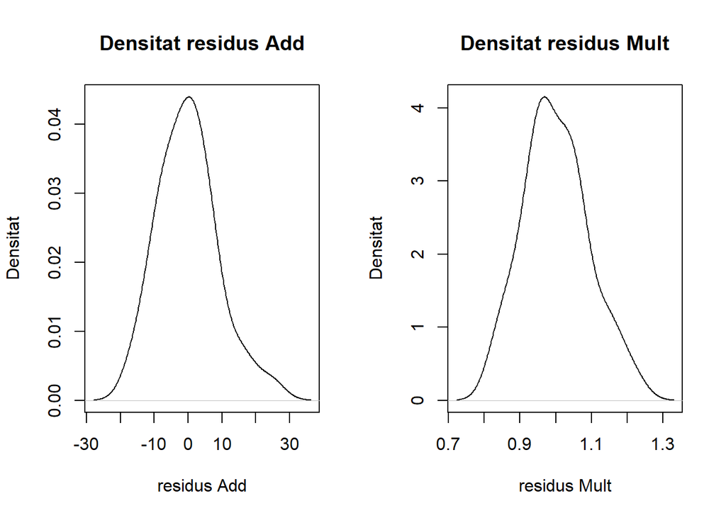

Farem un Shapiro test per veure si segueix notmalitat:

```
    Shapiro-Wilk normality test

data:  res_add
W = 0.97447, p-value = 0.5595
```

```
    Shapiro-Wilk normality test

data:  res_mult
W = 0.98113, p-value = 0.7828
```

Veim que en ambdós models obtenim residus que segueixen una distribució normal, en l’additiu amb mitjana 0 i en el multiplicatiu amb mitjana 1. A més, en el gràfic de la sèrie temporal dels residus es pot veure que la variància es manté més o manco constant.

Visualitzem els dos models sobre la sèrie original:

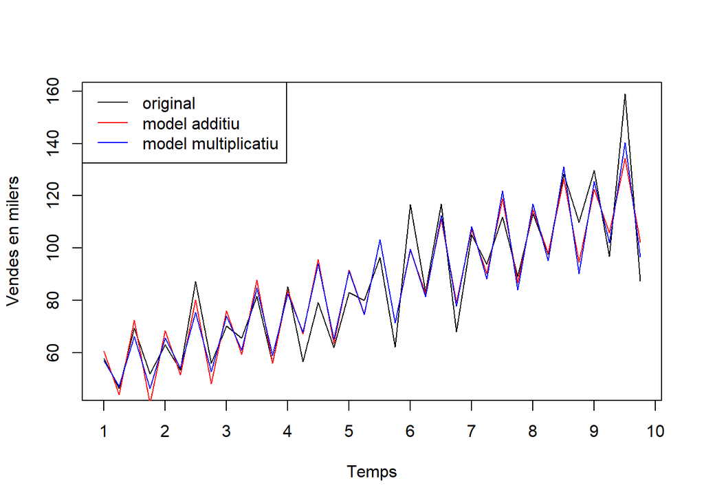

Calculam l’Error Quadràtic Mitjà (MSE) entre els models i les dades

```
[1] "Model additiu:        76.9027435682529"
```

```
[1] "Model multiplicatiu:  64.1098453899129"
```

En vista que el model multiplicatiu presenta un MSE menor, i té un p-valor major en el test de normalitat dels residus, seleccionarem aquest per fer les prediccions futures. Tot i això, ja que disposam de les dades futures, aplicarem els dos models per comparar quin és millor amb les previsions, tot i que a la pràctica ens quedaríem amb el multiplicatiu ja que s’ajusta millor a les dades existents.

## Pronòstic

Anem a intentar preveure, a partir dels models considerats, la sèrie temporal pels 12 termes restants. Per això, el que farem serà tenir en compte la tendència i l’estacionalitat. Recordem que la tendència l’aproximam amb una recta de regressió lineal (vista a l’inici del projecte). L’estacionalitat és periòdica, cada any és la mateixa, llavors el que farem serà repetir 3 vegades els 4 últims valors d’estacionalitat calculats anteriorment. El terme de renou no el tenim en compte per a la predicció, i per tant formarà part de l’error del model.

Anem a calcular primer l’estimació amb el model additiu. En aquest cas, sumam tendència amb estacionalitat:

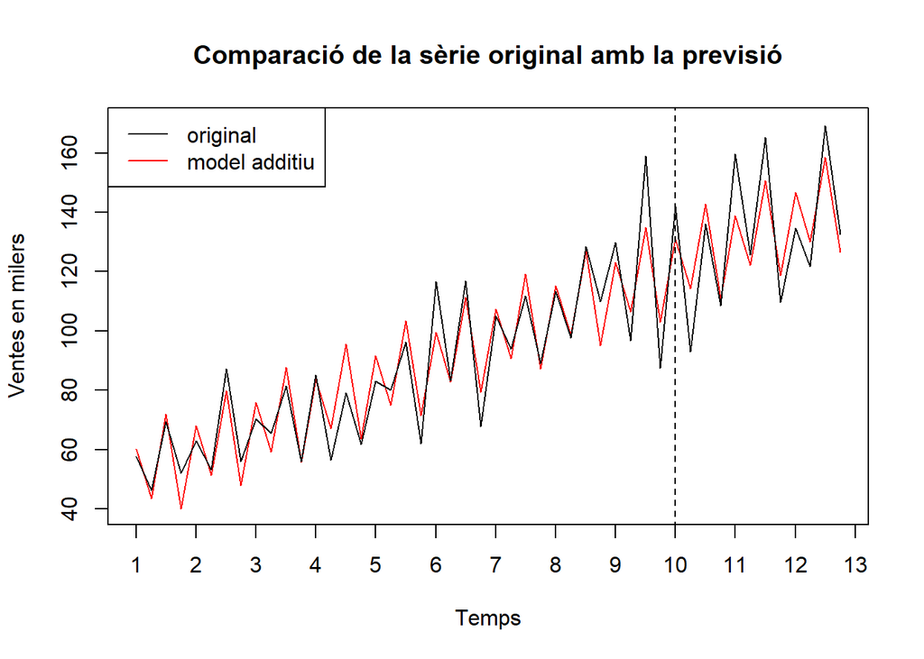

A simple vista la previsió més o manco s’ajusta però no en el mateix nivell que quan només miràvem les dades d’aprenentatge. Comprovem-ho calculant l’error quadràtic mitjà (MSE):

```
[1] 143.6664
```

Com podem veure, presenta un error major al de les dades ($143.66 > 76.9$).

De manera anàloga, calculem la predicció amb el model multiplicatiu. En aquest cas, multiplicam tendència i estacionalitat.

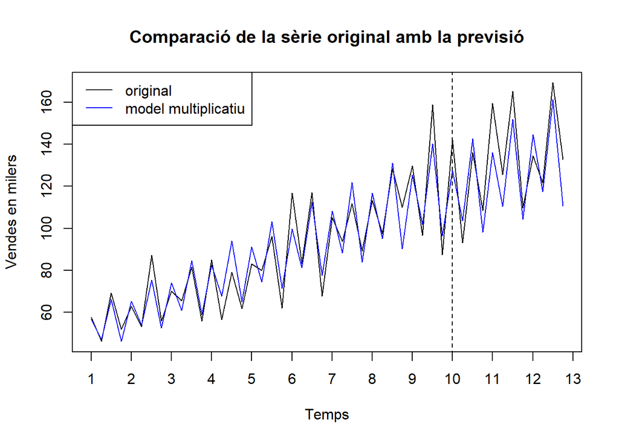

Veim que la previsió segueix el patró de la sèrie, però s’equivoca en les magnituds dels pics, i no se veu a simple vista una millora respecte l’additiu, sobretot per dos pics que queden bastant allunyats.

De nou, calculem l’error quadràtic mitjà de l’aproximació:

```
[1] 177.652
```

Pot parèixer sorprenent el fet que l’error sigui major al del model additiu, ja que havíem conclòs abans que el model multiplicatiu s’ajustava millor a les dades. Emperò, aquest cas es podia donar, idò que l’additiu s’ajusti pitjor a les dades no vol dir que per casualitat pronostiqui millor les dades futures.

Tot i això, notem que això ho hem pogut fer ja que disposàvem de les dades futures, idò en cas contrari ens haguéssim quedat només amb el multiplicatiu o haguéssim hagut d’esperar un parell d’anys per arribar en aquesta conclusió.

## Conclusions

Un cop hem finalitzat l’anàlisi de la sèrie temporal i hem fet les previsions, hem pogut concloure que la sèrie es modela prou bé amb els models additiu i multiplicatiu. Hem fet unes previsions dels següents 12 trimestres, gràcies a unes aproximacions de la tendència amb una recta de regressió lineal, on a partir d’aquí també hem aproximat l’estacionalitat. Hem observat i comparat els errors, i hem pogut concloure que el model multiplicatiu és lleugerament millor per estimar la sèrie, tot i que sorprenent el model additiu ha predit millor les dades futures.

En el context del problema concloem que, tot i que els models no s’ajusten perfectament a les dades, són prou bons i sí que capturen la forma de la sèrie, fins i tot en les prediccions encara que l’error sigui major.